# assignment6_20182480_문지원

문지원_20182480

2021 5 26

### [Sentiment Analysis on Twitter Dataset]

```r
# 라이브러리 추가
library(caret)
library(ISLR)
library(rsample)
library(rpart)
library(rpart.plot)
library(psych)
library(glmnet)
library(dplyr)
library(e1071)
library(dslabs)
library(mlbench)
library(randomForest)
library(wordcloud)
library(tm)
library(SnowballC)
library(vip)
```

#### 1.모델을 수립하기 전에 데이터의 특성을 분석한다. 시각화 도구를 적절히 활용하자.

```r
#read data
dat <- read.csv("Tweets_win.csv",stringsAsFactors = FALSE)
str(dat)
```

```
## 'data.frame':    14640 obs. of  15 variables:
##  $ tweet_id                    : num  5.7e+17 5.7e+17 5.7e+17 5.7e+17 5.7e+17 ...
##  $ airline_sentiment           : chr  "neutral" "positive" "neutral" "negative" ...
##  $ airline_sentiment_confidence: num  1 0.349 0.684 1 1 ...
##  $ negativereason              : chr  "" "" "" "Bad Flight" ...
##  $ negativereason_confidence   : num  NA 0 NA 0.703 1 ...
##  $ airline                     : chr  "Virgin America" "Virgin America" "Virgin America" "Virgin America" ...
##  $ airline_sentiment_gold      : chr  "" "" "" "" ...
##  $ name                        : chr  "cairdin" "jnardino" "yvonnalynn" "jnardino" ...
##  $ negativereason_gold         : chr  "" "" "" "" ...
##  $ retweet_count               : int  0 0 0 0 0 0 0 0 0 0 ...
##  $ text                        : chr  "@VirginAmerica What @dhepburn said." "@VirginAmerica plus you've added commercials to the experience... tacky." "@VirginAmerica I didn't today... Must mean I need to take another trip!" "@VirginAmerica it's really aggressive to blast obnoxious \"entertainmen…
##  $ tweet_coord                 : chr  "" "" "" "" ...
##  $ tweet_created               : chr  "2015-02-24 11:35" "2015-02-24 11:15" "2015-02-24 11:15" "2015-02-24 11:15" ...
##  $ tweet_location              : chr  "" "" "Lets Play" "" ...
##  $ user_timezone               : chr  "Eastern Time (US & Canada)" "Pacific Time (US & Canada)" "Central Time (US & Canada)" "Pacific Time (US & Canada)" ...
```

```r
dat <- dat[,c(2,11)]
str(dat)
```

```
## 'data.frame':    14640 obs. of  2 variables:
##  $ airline_sentiment: chr  "neutral" "positive" "neutral" "negative" ...
##  $ text             : chr  "@VirginAmerica What @dhepburn said." "@VirginAmerica plus you've added commercials to the experience... tacky." "@VirginAmerica I didn't today... Must mean I need to take another trip!" "@VirginAmerica it's really aggressive to blast obnoxious \"entertainment\" in your…
```

```r
#visualization

# target 변수 factor로 변환
dat$airline_sentiment <- factor(dat$airline_sentiment)
str(dat)
```

```
## 'data.frame':    14640 obs. of  2 variables:
##  $ airline_sentiment: Factor w/ 3 levels "negative","neutral",..: 2 3 2 1 1 1 3 2 3 3 ...
##  $ text             : chr  "@VirginAmerica What @dhepburn said." "@VirginAmerica plus you've added commercials to the experience... tacky." "@VirginAmerica I didn't today... Must mean I need to take another trip!" "@VirginAmerica it's really aggressive to blast obnoxious \"entertainment\" in your…
```

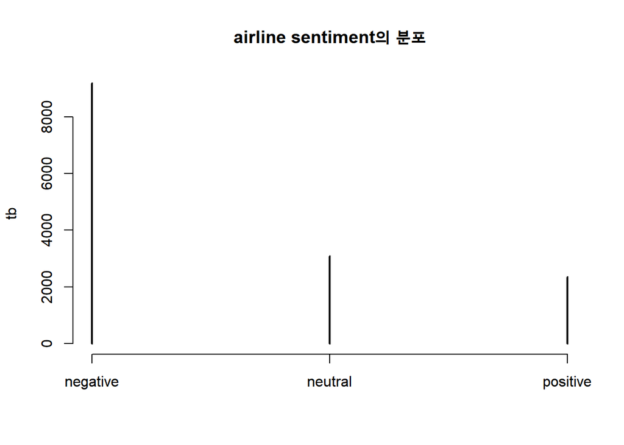

```r
# target 변수의 분포 확인
tb <- table(dat$airline_sentiment)
plot(tb, main="airline sentiment의 분포")
```

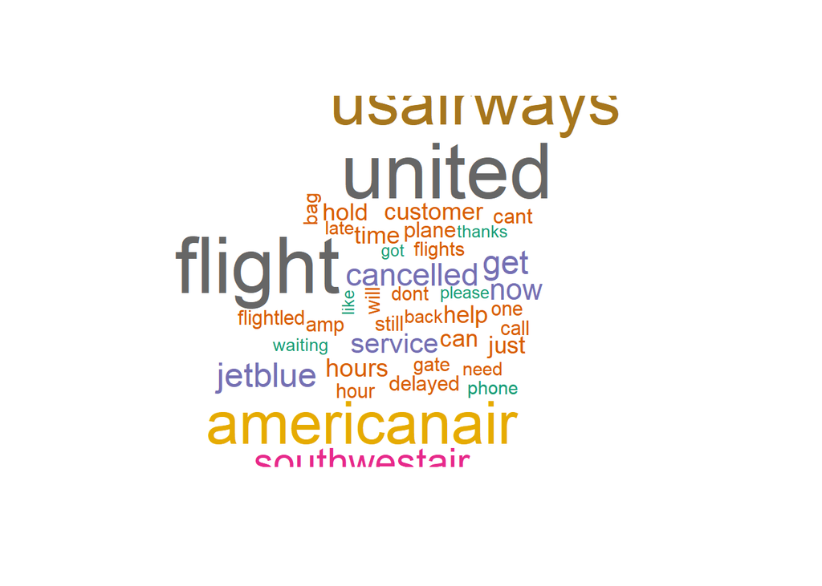

```r
# negative neutral positive 분리
negative <- subset(dat,airline_sentiment=="negative")
neutral <- subset(dat,airline_sentiment=="neutral")
positive <- subset(dat, airline_sentiment=="positive")

# wordcloud 생성
wordcloud(negative$text,max.words = 40,colors=brewer.pal(8,"Dark2"))
```

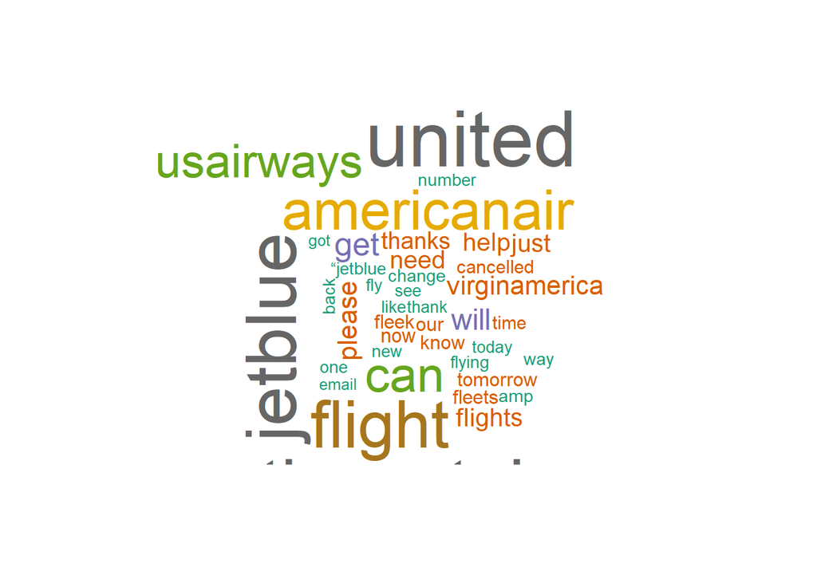

```r
wordcloud(neutral$text,max.words = 40,colors=brewer.pal(8,"Dark2"))
```

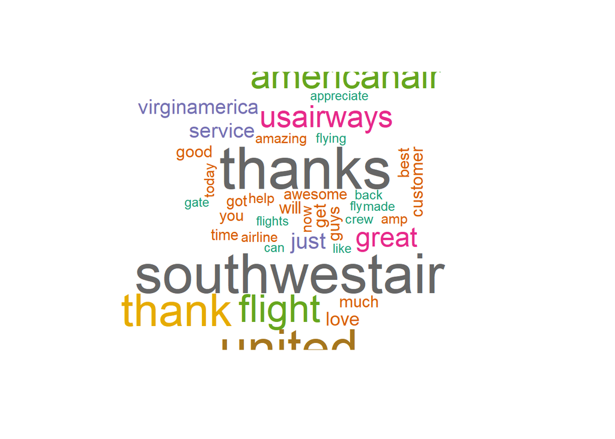

```r
wordcloud(positive$text,max.word = 40,colors=brewer.pal(8,"Dark2"))
```

**-결과해석**  
Airline sentiment의 분포를 table을 만들어 plot 해본 결과, 세가지 감정의 분포가 일정하지 않고 negative 변수의 분포가 neutral과positive 변수보다 월등히 높은 것을 확인할 수 있다.  
또한 wordcloud를 이용하여 텍스트에 빈번하게 등장하는 단어를 시각화 해 보았다. negative한 트윗에넌 flight, usairways,cancelled,hold등이 빈번하게 등장함을 알 수 있고, neutral한 트윗에는 united, americanair,jetblue 등이 빈번하게 등장함을 알 수 있고, positive한 트윗에는 thanks, southwestair, great 등이 빈번하게 등장함을 알 수 있다.

#### 2. 텍스트 데이터에 bag-of-words 기법을 적용하기 위해 적절한 preprocessing을 수행하고, 그 결과를 분석해보자.

```r
#create corpus
dat_corpus <- VCorpus(VectorSource(dat$text))
dat_corpus
```

```
## <<VCorpus>>
## Metadata:  corpus specific: 0, document level (indexed): 0
## Content:  documents: 14640
```

```r
#100번째 document 확인
inspect(dat_corpus[[110]])
```

```
## <<PlainTextDocument>>
## Metadata:  7
## Content:  chars: 133
##
## @VirginAmerica has getaway deals through May, from $59 one-way. Lots of cool cities http://t.co/tZZJhuIbCH #CheapFlights #FareCompare
```

```r
#대문자 소문자로 변환
dat_corpus_clean <- tm_map(dat_corpus,content_transformer(tolower))
dat_corpus_clean[[110]]$content
```

```
## [1] "@virginamerica has getaway deals through may, from $59 one-way. lots of cool cities http://t.co/tzzjhuibch #cheapflights #farecompare"
```

```r
#숫자 제거
dat_corpus_clean <- tm_map(dat_corpus_clean,removeNumbers)
dat_corpus_clean[[110]]$content
```

```
## [1] "@virginamerica has getaway deals through may, from $ one-way. lots of cool cities http://t.co/tzzjhuibch #cheapflights #farecompare"
```

```r
#stopword(불용어)제거
dat_corpus_clean <- tm_map(dat_corpus_clean,removeWords,stopwords())
dat_corpus_clean[[110]]$content
```

```
## [1] "@virginamerica  getaway deals  may,  $ one-way. lots  cool cities http://t.co/tzzjhuibch #cheapflights #farecompare"
```

```r
#문장부호 제거
dat_corpus_clean <- tm_map(dat_corpus_clean,removePunctuation)
dat_corpus_clean[[110]]$content
```

```
## [1] "virginamerica  getaway deals  may   oneway lots  cool cities httptcotzzjhuibch cheapflights farecompare"
```

```r
#단어들의 어미 제거(stemming)
dat_corpus_clean <- tm_map(dat_corpus_clean,stemDocument)
dat_corpus_clean[[110]]$content
```

```
## [1] "virginamerica getaway deal may oneway lot cool citi httptcotzzjhuibch cheapflight farecompar"
```

```r
#공백 제거
dat_corpus_clean <- tm_map(dat_corpus_clean,stripWhitespace)
dat_corpus_clean[[110]]$content
```

```
## [1] "virginamerica getaway deal may oneway lot cool citi httptcotzzjhuibch cheapflight farecompar"
```

**-결과해석**  
효과적인 데이터 분석을 위해 텍스트의 대문자를 소문자로 변환하고, 숫자를 제거하고, 불용어를 제거하고, 문장부호를 제거하고, 단어들의 어미를 제거하고, 공백을 제거하는 preprocessing을 수행한다.

#### 3. 계산시간을 줄이기 위해 첫 5,000개의 데이터만 training set으로 사용하고, 나머지 모든 데이터럴 test set으로 사용한다. Training set을 사용하여 predictive model을 만들어보자.

**DTM 사용하여 predictive model 만듦(DTM으로 최적 기법 선택한 후 그 기법 내에서 DTM과 TF-IDF 적용할 지 선택할 것임)**

```r
# create dtm
dat_dtm <- DocumentTermMatrix(dat_corpus_clean)
dat_dtm
```

```
## <<DocumentTermMatrix (documents: 14640, terms: 11284)>>
## Non-/sparse entries: 136434/165061326
## Sparsity           : 100%
## Maximal term length: 112
## Weighting          : term frequency (tf)
```

```r
inspect(dat_dtm[1:5,1:10])
```

```
## <<DocumentTermMatrix (documents: 5, terms: 10)>>
## Non-/sparse entries: 0/50
## Sparsity           : 100%
## Maximal term length: 14
## Weighting          : term frequency (tf)
## Sample             :
##     Terms
## Docs ‘connect’ ‘select ’ll ’re ’ve “americanair “ear “gay
##    1           0        0    0    0    0             0     0     0
##    2           0        0    0    0    0             0     0     0
##    3           0        0    0    0    0             0     0     0
##    4           0        0    0    0    0             0     0     0
##    5           0        0    0    0    0             0     0     0
##     Terms
## Docs “inconvenient” “jetblu
##    1                0        0
##    2                0        0
##    3                0        0
##    4                0        0
##    5                0        0
```

```r
#전체 documnet 중에 0.5% 미만의 document에서 발생하는 단어는 제외
dat_dtm2 <- removeSparseTerms(dat_dtm,0.995)
dat_dtm2
```

```
## <<DocumentTermMatrix (documents: 14640, terms: 330)>>
## Non-/sparse entries: 90846/4740354
## Sparsity           : 98%
## Maximal term length: 17
## Weighting          : term frequency (tf)
```

```r
#preprocessing 끝난 dtm을 데이터프레임으로 변환
data <- data.frame(as.matrix(dat_dtm2))

#feature 이름 적당한 형태로 조정
colnames(data) <- make.names(colnames(data))
str(data)
```

```
## 'data.frame':    14640 obs. of  330 variables:
##  $ X.jetblu         : num  0 0 0 0 0 0 0 0 0 0 ...
##  $ abl              : num  0 0 0 0 0 0 0 0 0 0 ...
##  $ account          : num  0 0 0 0 0 0 0 0 0 0 ...
##  $ actual           : num  0 0 0 0 0 0 0 0 0 0 ...
##  $ add              : num  0 0 0 0 0 0 0 0 0 0 ...
##  $ agent            : num  0 0 0 0 0 0 0 0 0 0 ...
##  $ ago              : num  0 0 0 0 0 0 0 0 0 0 ...
##  $ air              : num  0 0 0 0 0 0 0 0 0 0 ...
##  $ airlin           : num  0 0 0 0 0 0 0 0 0 0 ...
##  $ airport          : num  0 0 0 0 0 0 0 0 0 0 ...
##  $ airway           : num  0 0 0 0 0 0 0 0 0 0 ...
##  $ allow            : num  0 0 0 0 0 0 0 0 0 0 ...
##  $ almost           : num  0 0 0 0 0 0 0 0 0 0 ...
##  $ alreadi          : num  0 0 0 0 0 0 0 0 0 0 ...
```

[output cut: 86 more lines]

```r
#target 변수 추가
data$airline_sentiment <-dat$airline_sentiment

#데이터셋 분할
data_train <- data[1:5000,]
data_test <- data[5001:14640,]
```

#### A) 지금까지 학습한 모델을 최대한 활용해보고, 분석 과정과 결과를 report하자. 사용하는 모델, 모델에 포함되는 파라미터에 대한 튜닝, 모델에 포함되는 feature의 수, DTM/TF-IDF 사용 여부 등이 classification accuracy에 영향을 미칠 수 있다.

**k-NN algorithm 사용**

```r
set.seed(123)
knn_fit <- train(data=data_train, airline_sentiment~., method="knn", trControl = trainControl(method="cv", number = 5), preProcess = c("center", "scale"), tuneGrid = data.frame(k = seq(1, 30, 2)))
```

[output not shown]

[output not shown]

[output not shown]

[output not shown]

[output not shown]